# BINCOR: An R package for Estimating the Correlation between Two Unevenly Spaced Time Series

This paper presents a computational program named *BINCOR* (BINned CORrelation) for estimating the correlation between two unevenly spaced time series. This program is also applicable to the situation of two evenly spaced time series not on the same time grid. *BINCOR* is based on a novel estimation approach proposed by (Mudelsee 2010) for estimating the correlation between two climate time series with different timescales. The idea is that autocorrelation (e.g. an AR1 process) means that memory enables values obtained on different time points to be correlated. Binned correlation is performed by resampling the time series under study into time bins on a regular grid, assigning the mean values of the variable under scrutiny within those bins. We present two examples of our *BINCOR* package with real data: instrumental and paleoclimatic time series. In both applications *BINCOR* works properly in detecting well-established relationships between the climate records compared.

Josue M. Polanco-Martinez (Basque Centre for Climate Change - BC3) , Martin A. Medina-Elizalde (Dept. of Geosciences, Auburn University) , Maria F. Sanchez Goni (Ecole Pratique des Hautes Etudes (EPHE), PSL University) , Manfred Mudelsee (Climate Risk Analysis)  
2019-08-18

## 1 Introduction

There are several approaches for quantifying the potential association between two evenly spaced climate time series, e.g. Pearson’s and Spearman’s correlation or the cross-correlation function (CCF). However, these methods should not be directly applied when the time series are unevenly spaced (“irregular”), particularly when two time series under analysis are not sampled at identical points in time, as is usually the case in climate research, especially in paleoclimate studies (Weedon 2003; Mudelsee 2014; Emile-Geay 2016). The most common way of tackling this problem is to interpolate the original unevenly spaced climate time series in the time domain so as to obtain equidistance and the same times. The series can then be analysed using existing conventional correlation analysis techniques. However, experience shows that interpolation has its drawbacks: depending on the features of the method applied, the interpolated time series may show deviations in terms of variability or noise properties, and additional serial dependence may be introduced (Horowitz 1974; Mudelsee 2014; Olafsdottir and Mudelsee 2014). Thus, interpolation should be avoided as far as possible.

Fortunately, there are some algorithms and software available to carry out this task, at least for unevenly spaced climate time series sampled at identical points in time (Mudelsee 2003; Olafsdottir and Mudelsee 2014). However, there are few statistical techniques for estimating the correlation between two time series not sampled at identical points in time and their corresponding computational implementations. One exception is the Gaussian-Kernel-based cross-correlation (gXCF) method and its associated software named NESTOOLBOX (Rehfeld et al. 2011; Rehfeld and Bedartha 2014; Rehfeld and Kurths 2014) and the extended version (Roberts et al. 2017) that includes a confidence interval obtained by a bootstrapping resampling approach; another exception is binned correlation as proposed by (Mudelsee 2010, 2014). However, the software for this method is not freely available on the Internet.

Binned correlation is a statistical technique developed to estimate the correlation between two unevenly spaced time series sampled at different points in time. It is also applicable to two evenly spaced time series that are not on the same time grid (Mudelsee 2014). It is performed by resampling the time series into time bins on a regular grid, and then assigning the mean values of the variable under scrutiny within those bins. (Mudelsee 2010) proposes a novel approach adapting the binned correlation technique (used mainly with astronomical data) to analyse climate time series taking into account their memory (or persistence), which is a genuine property of climate time series. Autocorrelation, persistence, memory or serial dependence is characteristic of weather and climate fluctuations, and is recorded in climate time series (Mudelsee 2002; Wilks 2011). A simple persistence model used to “represent” climate time series is a first-order autoregressive (AR1) process where a fluctuation depends only on its own immediate past plus a random component (Gilman et al. 1963; Mann and Lees 1996; Mudelsee 2002). However, paleoclimate time series are usually unevenly spaced in time, and it is necessary to use an AR1 version for the case of uneven spacing, such as the method proposed by (Robinson 1977). The technique of (Mudelsee 2010) requires the concept of nonzero persistence times, enabling the mixing information (i.e. covariance) to be recovered, even when the two timescales differ. The [*BINCOR*](https://CRAN.R-project.org/package=BINCOR) package presented in this paper is based on a method that is not applicable when one or both of the time series under examination have zero persistence. Similarly, this method is not applicable when the time series are sampled with significantly longer spacing than the persistence time, so that the effectively sampled persistence time is zero. A fundamental condition for using this method is that the time spacing should not be much larger than the persistence times. Enough common data points then fall within a time bin, and knowledge can be acquired on the covariance (Mudelsee 2010, 2014).

In this paper we present a computational package named *BINCOR* (BINned CORrelation), which is based on the approach proposed by (Mudelsee 2010, 2014). The *BINCOR* package contains (i) a main function named `bin_cor`, which is used to convert the irregular time series to a binned time series; (ii) two complementary functions (`cor_ts` and `ccf_ts`) for computing the correlation between the two binned climate time series obtained with the `bin_cor` function; and (iii) an additional function (`plot_ts`) for plotting the “primary” vs. the binned time series. This package is programmed in `R` language and is available at the CRAN repository (https://CRAN.R-project.org/package=BINCOR).

This paper is divided into four sections. The first outlines the method and the computational program. The second presents a Monte Carlo experiment to study the effect of binning size selection. In the Examples section we apply *BINCOR* to a couple of unevenly spaced real-world climate data sets: instrumental and paleoclimate. Finally, the Summary section presents our main conclusions.

## 2 The BINCOR package

### 2.1 The method

In this section we outline the main mathematical ideas behind the binned correlation technique for unevenly spaced sampled at different points in time, following the methodology introduced by (Mudelsee 2010, 2014). The procedure is described as follows:

1. Input: two unevenly spaced climate time series $\{X(i), T_X\}_{i=1}^{N_X}$ and $\{Y(i), T_Y\}_{i=1}^{N_Y}$, where $T_X$, $T_Y$ and $N_Y$, $N_Y$ are the time domains and the sample sizes of each series, respectively.
2. Compute the average spacing between samples
   - $\bar{d}_X = [T_X(N_X) - T_X(1)]/(N_X - 1)$
   - $\bar{d}_Y = [T_Y(N_X) - T_Y(1)]/(N_Y - 1)$
   - $\bar{d}_{XY} = [\bar{T}_\mathrm{max} - \bar{T}_\mathrm{min}]/(N_X + N_Y - 1)$

     Table 1: The FLAGTAU options and its corresponding methods (rules) to estimate the bin-width.

     | $\bar{\tau}$ rule | FLAGTAU option | Reference |  |
     | --- | --- | --- | --- |
     | $\tau_x + \tau_y$ | 1 | Eq. 7.44 in (Mudelsee 2014) |  |
     | $\mathrm{max}(\tau_x, \tau_y)$ | 2 | Eq. 7.45 in (Mudelsee 2014) |  |
     | $-\bar{d}_{XY} / \ln (\hat{\bar{a}}'_{XY})$ | 3 | Eq. 7.48 in (Mudelsee 2014) |  |

4. Determine the number of bins: $N_b = (\bar{T}_\mathrm{max} - \bar{T}_\mathrm{min}) / \bar{\tau}$
5. Set: $\lim_\mathrm{inf}(n=1) = \bar{T}_\mathrm{min}$. Then, for $n=1, 2, \dots, N_b$, define (Figure 1):
   1. $\lim_\mathrm{sup}(n) = \bar{T}_\mathrm{min} + n \cdot \bar{\tau}$
   2. id$T_X$ = WHICH $[T_X \geq \lim_\mathrm{inf}(n)$ AND $T_X \leq \lim_\mathrm{sup}(n)]$
   3. id$T_Y$ = WHICH $[T_Y \geq \lim_\mathrm{inf}(n)$ AND $T_Y \leq \lim_{sup}(n)]$
   4. L$T_X$ = LENGTH(id$T_X$)
   5. L$T_Y$ = LENGTH(id$T_Y$)

      if (L$T_X$ $>$ 0 AND L$T_Y$ $>$ 0)
      1. $F(n)$ = mean of $X$(id$T_X$)
      2. $G(n)$ = mean of $Y$(id$T_Y$)
      3. $T(n)$ = [$\lim_\mathrm{inf}(n)$ + $\lim_\mathrm{sup}(n)$] / 2
   6. $\lim_\mathrm{inf}(n) = \lim_\mathrm{sup}(n)$
6. Output: two binned climate time series $\{T_n,\, F(n)\}_{n=1}^{N_b}$ and $\{T_n, G(n)\}_{n=1}^{N_b}$, where $N_b$ is the number of bins.
7. Estimate the correlation between the two binned time series. This can be done through the native `R` functions `cor` and `ccf` or by means of the *BINCOR* functions `cor_ts` and `ccf_ts`.

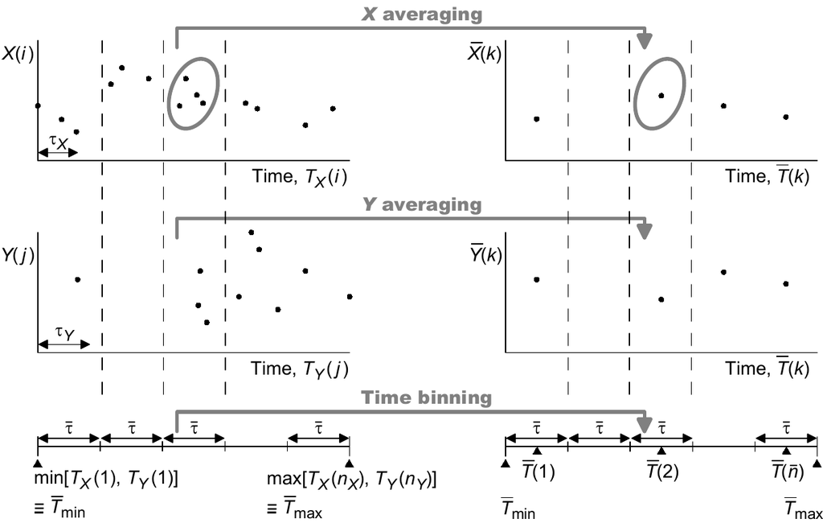

Figure 1: Graphical representation for the binned correlation procedure presented in Step 5. Modified from (Mudelsee 2010, 2014).

## 3 Monte Carlo experiments

We conducted Monte Carlo experiments to study how the specific rules (Table 1) chosen for calculating the bin-width based on persistence reduce the error compared to arbitrarily choosing a bin-width. The parameter configuration for the Monte Carlo experiments is presented in Figure 2. To carry out the Monte Carlo simulations, we used the bivariate Gaussian AR1 process for uneven time spacings (Mudelsee 2014), which is given by

$$\begin{aligned}
~\label{biAR1-1}
X(1) = \mu_{N(0,1)}^{X}(1), \nonumber \\
Y(1) = \mu_{N(0,1)}^{Y}(1), \nonumber \\
X(t) = a_X X(t-1) + \mu_{N(0,1-a_X^2)}^{X}(t), \;\; t= 2,...,N,\nonumber \\
Y(t) = a_Y Y(t-1) + \mu_{N(0,1-a_Y^2)}^{Y}(t), \;\; t= 2,...,N,
\end{aligned} \tag{1}$$

where $a_X$ and $a_Y$, the autoregressive parameters for $X(t)$ and $Y(t)$, are defined as (Mudelsee 2014): $a_X = exp\{-[T_X(t) - T_X(t-1)]/\tau_X\}$ and $a_Y = exp\{-[T_Y(t) - T_Y(t-1)]/\tau_Y\}$. The correlation (by construction) between $X(t)$ and $Y(t)$ is $\rho_{XY}$ (see Mudelsee 2014 307 for more details about the statistical properties of the bivariate AR1 process for unevenly spaced time series). To generate the uneven timescales for $X(i)$ and $Y(j)$, we follow the methodology proposed by (see Mudelsee 2014 299), which consists of producing a number (10 $N$) of data pairs on an evenly spaced grid of 1.0, discarding 90% of points and retaining 10% of $X$ and $Y$ ($N_x=N_y=N$) points. The time points for $X(i)$ and $Y(j)$ are subject to the following conditions:

1. Control case (equal timescales):
   - Condition 1: $N_X=N_Y$
   - Condition 2: $\{T_X(i)\}_{i=1}^{N_X}=\{T_Y(j)\}_{j=1}^{N_Y}$
2. “Well” mixed unequal timescales:
   - Condition 1: $T_X(i) \neq T_Y(j) \; for all \; i \; and \; j$
   - Condition 2: $T_X(1) < T_Y(1) < T_X(2) < T_Y(2) < T_X(3) < ... < T_X(N_X) < T_Y(N_Y)$
3. “Wildly” mixed unequal timescales:
   - There are not conditions for this case.

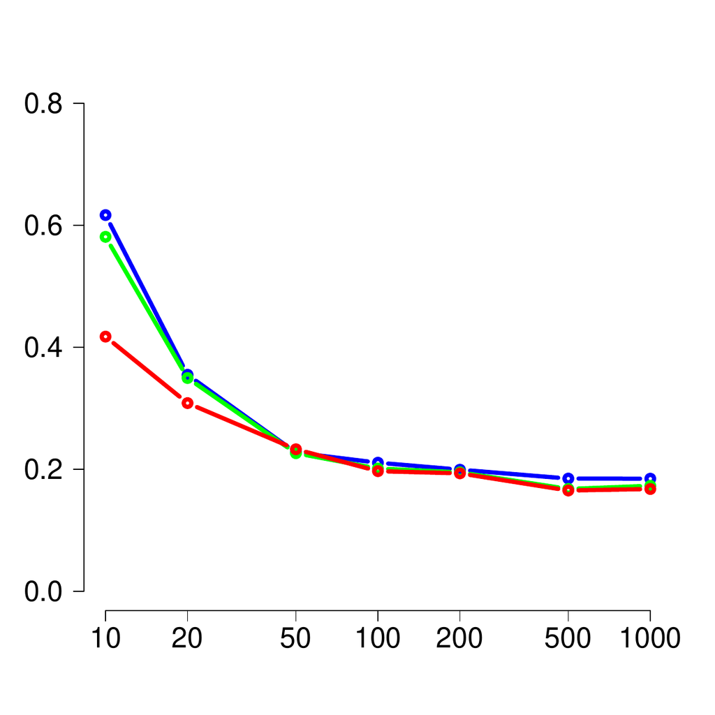

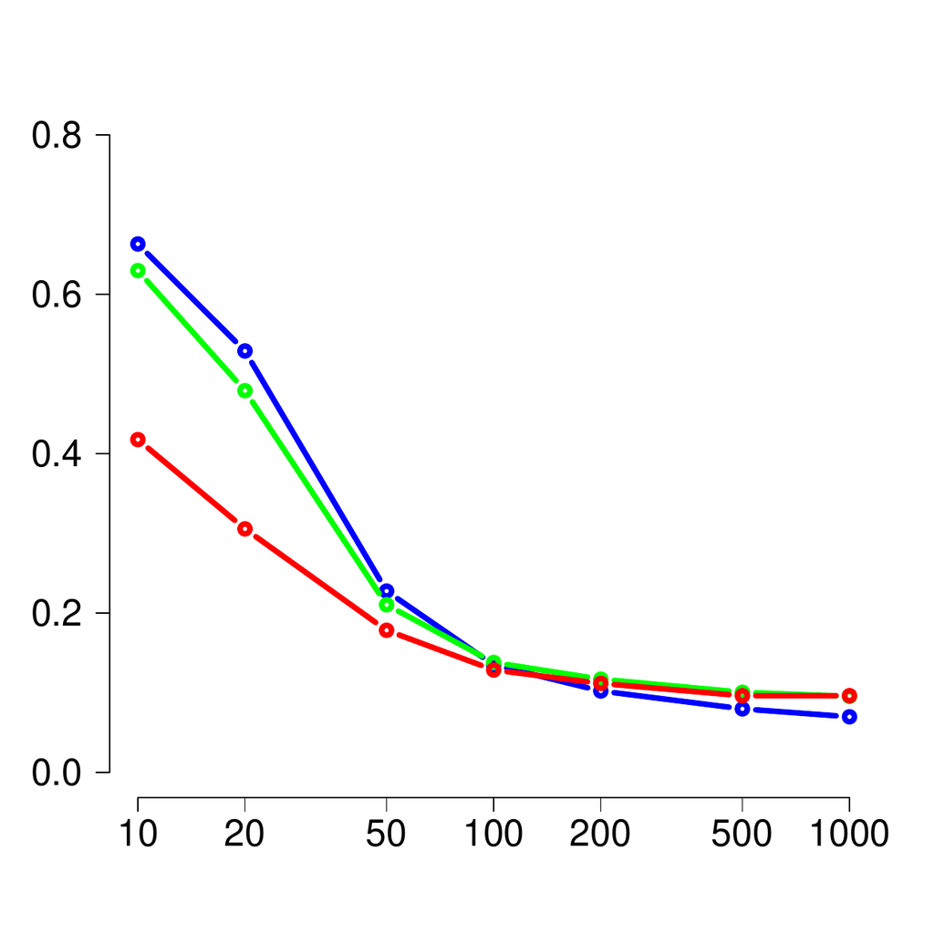

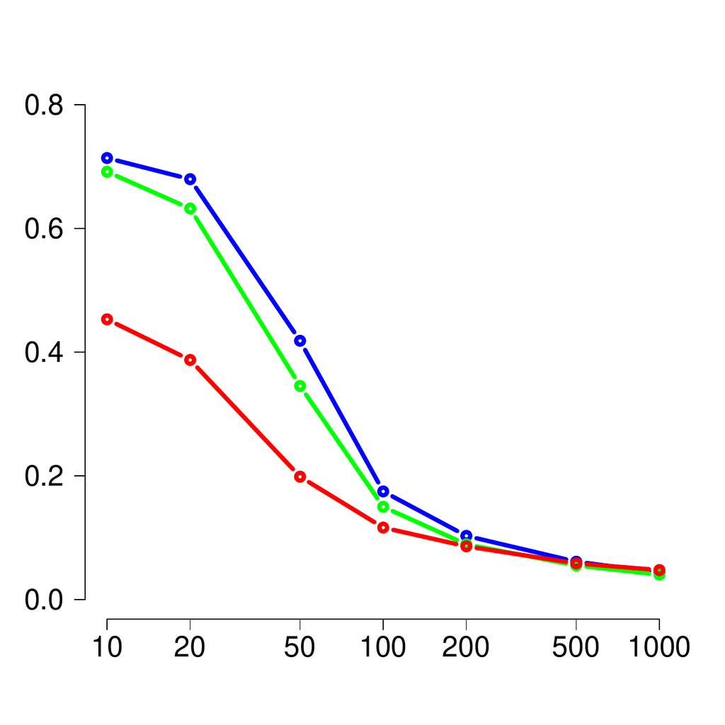

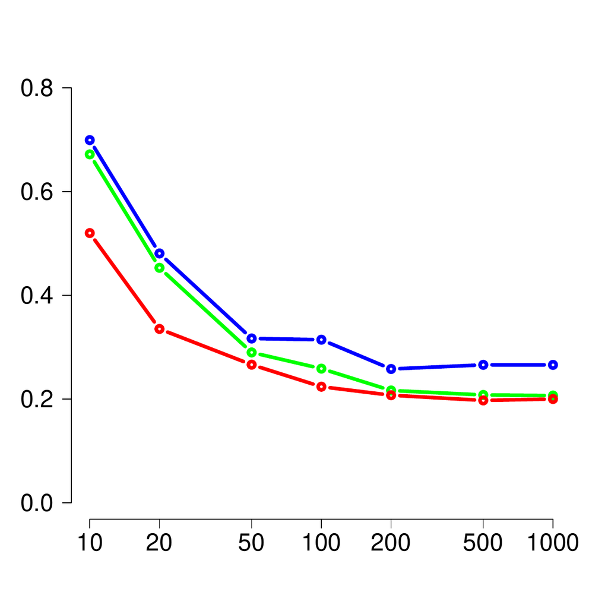

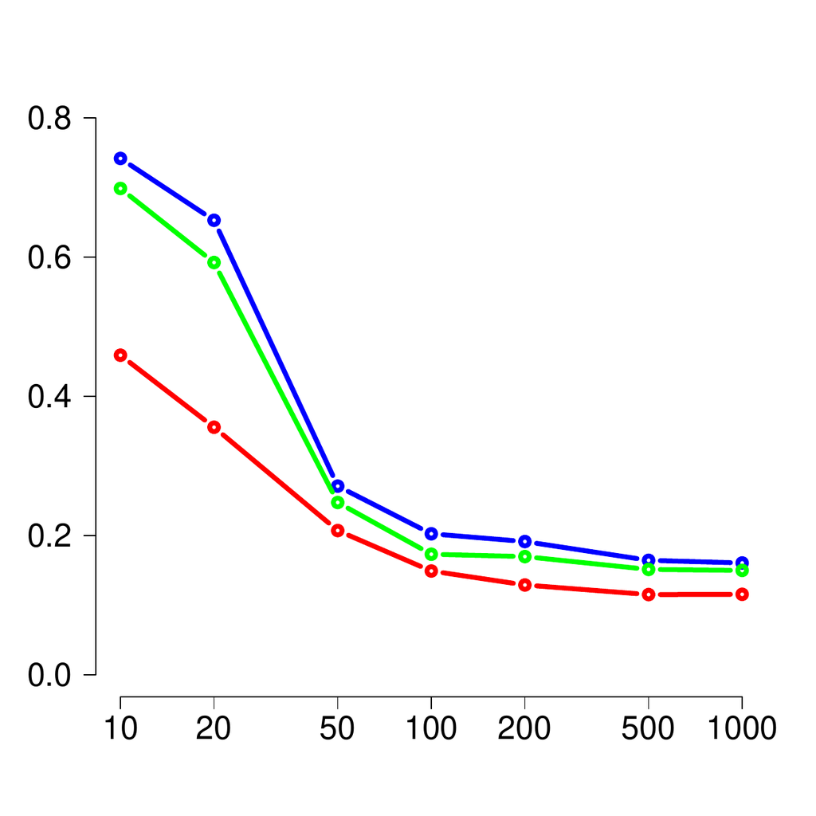

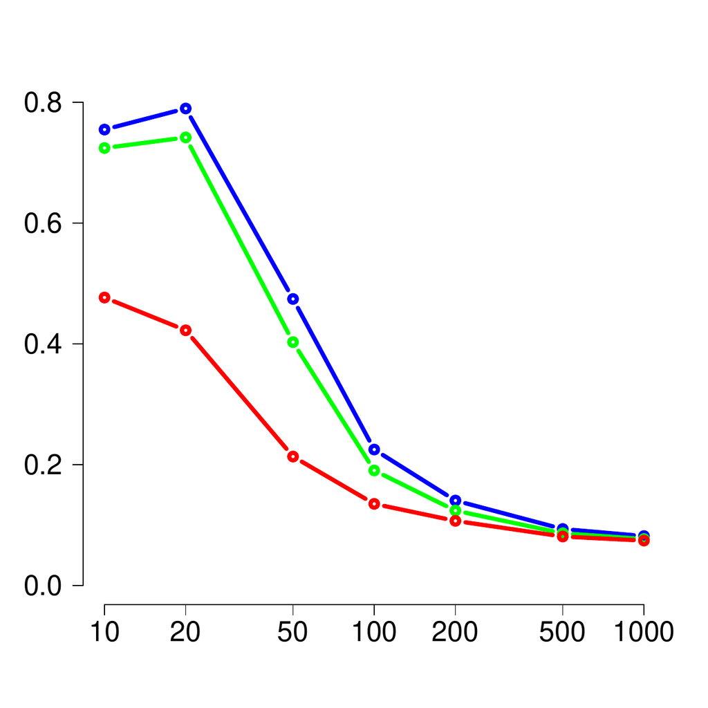

Figure 2: Monte Carlo experiments to test the impact of the rules (Table ) used to calculate the bin-width and their role in the estimation of the binned correlation. The persistence figures for *X* and *Y* are 10 (column 1), 20 (column 2) and 50 (column 3), respectively. The constraints for the resampling timescales are for well mixed (first row) and wildly mixed (second row) cases. The horizontal axis indicates the sample sizes (in log10 scale) and the vertical axis shows the RMSE that is determined via averaging (*ρ̂*<sub>*X**Y*</sub>−*ρ*<sub>*X**Y*</sub>)<sup>2</sup> over 5,000 simulations. The blue, green and red curves indicate rules 1 (sum), 2 (max) and 3 (the default rule option in *BINCOR*).

The outcome of the Monte Carlo experiments is as follows: 1) For equal timescales (figures not shown), all three rules behave similarly (as expected) in terms of RMSE, although the RMSE increases slightly as the persistence increases. 2) The well mixed case shows that for RMSE the rules take two different “patterns” with the first two rules (sum and max) on one hand and the third rule (the default rule option) on the other. This difference is most noticeable in the first values of the samples (from 10 to 100) and is most pronounced with high persistence values ($\tau_x$ and $\tau_y$). The rule that shows the smallest RMSE is rule 3 (the default option), though it is important to point out that for $\tau_x = \tau_y$ = 50 the RMSE figures are practically indistinguishable for sample sizes from 200 to 1000. 3) Finally, RMSE in the wildly mixed case behaves more or less similarly to the well mixed case, though rule 3 yields the smallest RMSE for all three persistence values. Bearing in mind that the wildly mixed case does not impose conditions on generating timescales, and in practice the unevenly spaced climate time series could contain some degree of randomness in the sampling times, the best rule in terms of RMSE for estimating bin-width ($\bar{\tau}$) and binned correlation can be said to be number 3, i.e. the default rule used in *BINCOR* to estimate the bin-width.

### 3.1 The computer program

The *BINCOR* package developed in `R` version 3.1.2 to be run from the command line runs on all major operating systems and is available from the CRAN repository (http://CRAN.R-project.org/package=BINCOR). The *BINCOR* package contains four functions: 1) `bin_cor` (the main function for building the binned time series); 2) `plot_ts` (for plotting and comparing the “primary” and binned time series); 3) `cor_ts` (for estimating the correlation between the binned time series); and 4) `ccf_ts` (for estimating the cross-correlation between the binned time series). The graphical outputs can be displayed on the screen or saved as PNG, JPG, or PDF graphics files. *BINCOR* depends on the [*dplR*](https://CRAN.R-project.org/package=dplR) (Bunn et al. 2015) and [*pracma*](https://CRAN.R-project.org/package=pracma) (Borchers 2015) packages. The [*dplR*](https://CRAN.R-project.org/package=dplR) package is used by the function `bin_cor` to calculate the persistence for the climate time series under study, whereas the [*pracma*](https://CRAN.R-project.org/package=pracma) package is used by the functions `cor_ts` and `ccf_ts` to remove the linear trend before estimating the correlation.

The first (and main) function, `bin_cor`, estimates the binned time series taking into account the memory or persistence of the unevenly spaced climate time series to be analysed (Mudelsee 2002). It has the following syntax:

```r
  R> bin_cor(ts1, ts2, FLAGTAU=3, ofilename),
```

where

- `ts1` and `ts2` are unevenly spaced time series.
- `FLAGTAU` defines the method used to estimate the bin-width ($\bar{\tau}$). There are three methods included in *BINCOR* for estimating bin-width (Table 1), but we prefer to use (`FLAGTAU = 3`) as the default rule because Monte Carlo simulations perform better in terms of RMSE than the other rules in estimating the bin-width and the binned correlations (Mudelsee 2014).
- `ofilename` is the name of the output file (in ASCII format) which contains the binned time series.

`bin_cor` returns a list object containing the following outputs:

```r
 "Binned_time_series", "Auto._cor._coef._ts1", "Persistence_ts1", "Auto._cor._coef._ts2",
 "Persistence_ts2", "bin width", "Number_of_bins",  "Average spacing", "VAR. ts1",
 "VAR. bin ts1", "VAR. ts2", "VAR. bin ts2", "VAR. ts1 - VAR bints1",
 "VAR. ts2 - VAR bints2", "% of VAR. lost ts1", "% of VAR. lost ts2".
```

The names of the outputs are self-explanatory, but we wish to highlight that `Average spacing` is the mean value of the times for the binned time series; `VAR. ts1`, `VAR. bin ts1`, `VAR. ts2` and `VAR. bin ts2` are the variances for `ts1` and `ts2` for their respective binned time series; the next two outputs are the differences between the variances of `ts1` and `ts2` and their corresponding binned time series; and the last two outputs are the percentages of variance lost for `ts1` and `ts2` as a result of the binned process.

The second function, called `plot_ts`, plots the “primary” (unevenly spaced) time series and the binned time series. The `plot_ts` function contains the following elements:

```r
 R> plot_ts(ts1, ts2, bints1, bints2, varnamets1="", varnamets2="",
    colts1=1, colts2=1, colbints1=2, colbints2=2, ltyts1=1,
    ltyts2=1, ltybints1=2, ltybints2=2, device="screen", ofilename),
```

where the input arguments `ts1` and `ts2` are the unevenly spaced time series, `bints1` and `bints2` are the binned time series, `varnamets1` and `varnamets2` are the names of the variables under study, `colts1`, `colts2` (by default both curves are in black) and `colbints1`, `colbints2` (by default both curves are in red) are the colours for the “primary” and binned times series; `ltyts1`, `ltyts2`, `ltybints1` and `ltybints2` are the types of line to be plotted for the “primary” and binned times series, respectively (1 = solid, 2 = dashed, 3 = dotted, 4 = dot-dashed, 5 = long-dashed, 6 = double-dashed); `device` is the type of output device (“screen” by default, the other options being “jpg,” “png,” and “pdf”); `resfig` is the image resolution in “ppi” (by default `R` does not record a resolution in the image file, except for BMP; 150 ppi could be a suitable value); `ofilename` is the output filename; and finally, `Hfig`, `WFig` and `Hpdf`, `Wpdf` are the height and width of the output for the JPG/PNG and PDF formats, respectively.

The third function, `cor_ts`, calculates three types of correlation coefficient: Pearson’s correlation, Spearman’s and Kendall’s rank correlations. These correlation coefficients are estimated through the native `R` function `cor.test` from the `R` package `Stats`. The `cor_ts` function has an option to remove the linear trend of the time series under analysis – other pre-processing methods could be used before the `cor_ts` function is applied. This function has the following syntax:

```r
 R> cor_ts(bints1, bints2, varnamets1="", varnamets2="",
    KoCM, rmltrd="N", device="screen", Hfig, Wfig, Hpdf, Wpdf,
    resfig, ofilename)
```

where `KoCM` indicates the correlation estimator: `pearson` for Pearson (the option by default), `spearman` for Spearman and `kendall` for Kendall; `rmltrd` is the option to remove the linear trend in the time series under study (by default the linear trend is not removed, but the function can be enabled via the option “Y” or “y”). The other parameters are described some lines above. `cor_ts` has as its output a list object containing the main information for the estimated correlation coefficient (e.g. a 95% confidence interval for Pearson and a `p-value` for Spearman and Kendall). The `cor_ts` function also provides a scatterplot for the binned time series, which can be plotted on the screen (by default) or saved in JPG, PNG or PDF formats (the parameter `ofilename` is available to assign a name to this output).

Finally, the fourth function, `ccf_ts`, estimates and plots the cross-correlation between two evenly spaced paleoclimate time series. We use the native `R` function `ccf` (`R` `Stats` package) to estimate the cross-correlation in our `ccf_ts` function. The `ccf_ts` function has the following syntax:

```r
  R> ccf_acf <- ccf_ts(bints1, bints2, lagmax=NULL, ylima=-1, ylimb=1,
            rmltrd="N", RedL=T, device="screen", Hfig, Wfig,
            Hpdf, Wpdf, resfig, ofilename)
```

All these elements are already defined above except the parameters `lagmax=NULL`, `ylima=-1`, `ylimb=1` and `RedL`. The first parameter indicates the maximum lag for which the cross-correlation is calculated (its value depends on the length of the data set), the next two parameters indicate the extremes of the range in which the CCF will be plotted and the last parameter (the default option is TRUE) plots a straight red line to highlight the correlation coefficient at lag 0. The `ccf_ts` function generates as its output the `acf` (auto-correlation function; ACF) `R` object, which is a list with the following parameters: `lag` is a three dimensional array containing the lags at which the ACF is estimated; `acf` is an array with the same dimensions as `lag` containing the estimated ACF; `type` is the type of correlation (`correlation` (the default), `covariance` and `partial`); `n.used` is the number of observations in the time series; and `snames` provides the names of the time series (`bints1` and `bints2`).

## 4 Examples

### 4.1 Assessing the link between El Niño-Southern Oscillation and Northern Hemisphere sea surface temperature

We first examine two evenly-spaced annually-resolved instrumental climate records that cover the time interval from 1850 to 2006 ($N = 157$ points). To test our *BINCOR* package we created irregular time series by randomly removing 20% of the data from the evenly spaced time series. We note that the new “sampling” times are not necessarily the same for both irregular series. The new irregular time series (“primary” hereafter) consist of 125 data points and have an average temporal spacing $\bar{d}$ of 1.24 years. Specifically the two time series used were a record of Northern Hemisphere (NH) sea surface temperature (SST) anomalies (HadCRUT3, (Brohan et al. 2006)) and a record of equatorial Pacific SST anomalies from the El Niño 3 region (2.5$^\circ$S to 2.5$^\circ$N, 92.5 to 147.5$^\circ$W) (Mann et al. 2009), which is a indicator of El Niño-Southern Oscillation (ENSO). Both time series, especially the NH-SST data, show strong autocorrelation (plots not shown) and long-term trends (inspected by Mann-Kendall test; ENSO, `z`=6.52 and `p-value` $<$ 0.001 and NH-SST, `z` = 10.214 and `p-value` $<$ 0.001). To generate the sample data, we fit a linear model to each evenly spaced time series and, after removing the model fitted to the evenly spaced data, we use the residuals (i.e. the difference between the observed data and the model fitted) to build the irregular time series and then create the binned time series.

A)

C)

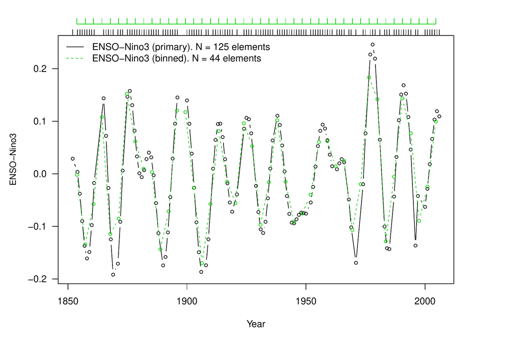

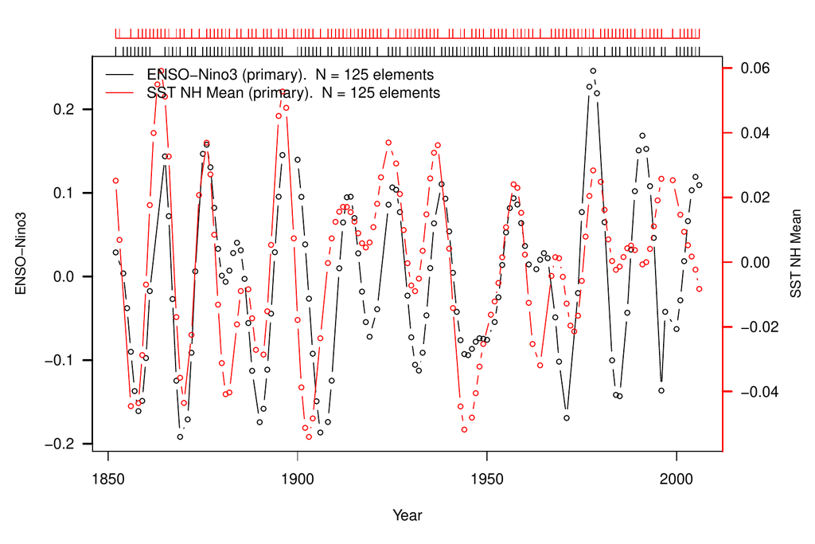

B)

D)

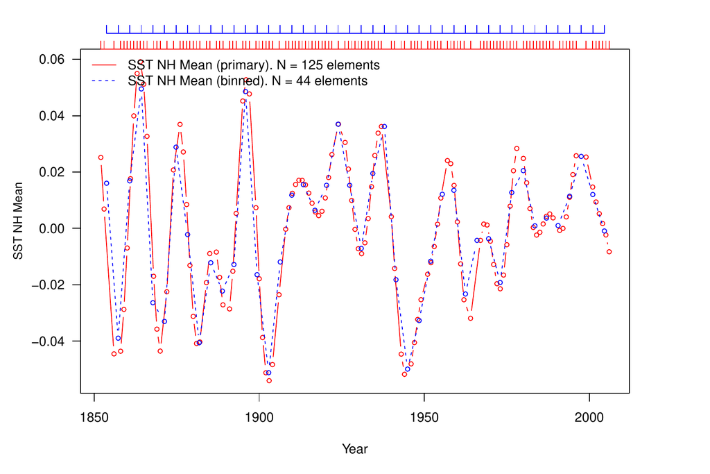

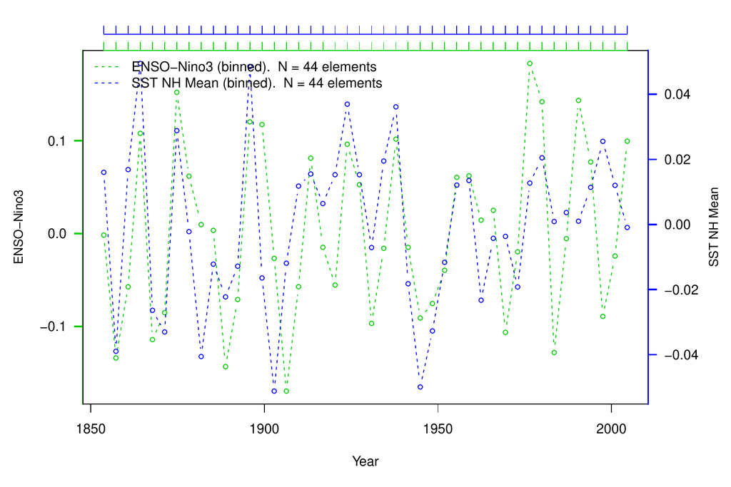

Figure 3: “Primary” (unevenly spaced) and binned ENSO-Niño3 (Mann et al. 2009) and NH-SST (Brohan et al. 2006). The autocorrelation and persistence values for ENSO are $\hat{\bar{a}}' = 0.82$ and *τ̂* = 6.25 years, and for NH-SST are $\hat{\bar{a}}' = 0.86$ and *τ̄* = 8.05 years. The horizontal top axes indicate the sampling times for the plotted time series.

The code used to generate Figure 3 is shown below.

```r
 # Load the package
 library(BINCOR)

 # Load the time series under analysis: Example 1 and Figure 1 (ENSO vs. NHSST)
 data(ENSO)
 data(NHSST)

 # Compute the binned time series though our bin_cor function
 bincor.tmp <- bin_cor(ENSO.dat, NHSST.dat, FLAGTAU=3, "output_ENSO_NHSST.tmp")
 binnedts   <- bincor.tmp$Binned_time_series

 # Applying our plot_ts function
 # "Screen"
 plot_ts(ENSO.dat, NHSST.dat, binnedts[,1:2], binnedts[,c(1,3)], "ENSO-Nino3",
 "SST NH Mean", colts1=1, colts2=2, colbints1=3, colbints2=4, device="screen")
```

The second result obtained from our *BINCOR* package, and more specifically from the `cor_ts` function, is shown in Figure 4, which shows the scatterplot between the ENSO (x-axis) and NH-SST (y-axis) binned time series. This scatterplot shows a moderate increasing trend from left to right, suggesting a potentially positive relationship between the two binned time series. This pattern can be confirmed statistically by means of the `cor_ts` function output, which also provides the correlation coefficient between two time series under analysis. For this case, the Pearson’s correlation (with 95% confidence interval) obtained is $\bar{r}_{XY} = 0.53$ [0.28; 0.71] (other estimators can also be used in `cor_ts`). This value is close to the Pearson’s correlation estimated for the evenly spaced climate time series, which is $\bar{r}_{XY} = 0.58$ [0.46; 0.67]. The relatively high correlation obtained between these two climate records is expected; ENSO-related climate variability is observed in many regions outside the equatorial Pacific, particularly in the tropical North Atlantic (Enfield and Mayer 1997; Garcia-Serrano et al. 2017).

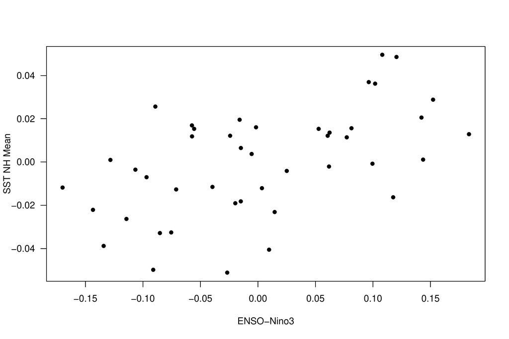

Figure 4: Scatterplot for the ENSO-Niño3 (Mann et al. 2009) and NH-SST (Brohan et al. 2006) binned time series. The Pearson’s correlation coefficient (with 95% confidence interval) is $\bar{r}_{XY} = 0.53$ [0.28; 0.71].

```r
 # Load packages
 library(BINCOR)
 library(pracma)

 # Load the time series under analysis: Example 1 and Figure 2 (ENSO vs. NHSST)
 data(ENSO)
 data(NHSST)

 # Compute the binned time series though our bin_cor function
 bincor.tmp <- bin_cor(ENSO.dat, NHSST.dat, FLAGTAU=3, "output_ENSO_NHSST.tmp")
 binnedts   <- bincor.tmp$Binned_time_series

 # Compute the scatterplot by means of our function cor_ts
 # PDF format (scatterplot) and Pearson
 cor_ts(binnedts[,1:2], binnedts[,c(1,3)], "ENSO-Nino3", "SST NH Mean",
 KoCM="pearson", rmltrd="y", device="pdf", Hpdf=6, Wpdf=9, resfig=300,
 ofilename="scatterplot_ENSO_SST")
```

### 4.2 Abrupt climate changes during the last glacial

We report an analysis of two temporally unevenly-spaced pollen records from two marine sediment cores (MD04 and MD95) collected on the south-western European margin (Figure 5). The aim of this case study is to show the use of *BINCOR* to estimate the correlation between two unevenly spaced paleoclimate time series by means of the cross-correlation function. The pollen time series analysed in this example span the interval between 73,000 and 15,000 years before present (BP), thus covering the last glacial period (LGP). The climate during the LGP was characterised by millennial variability with “abrupt” transitions between cold stadials and warm interstadials known as Dansgaard-Oeschger (D-O) cycles (Dansgaard et al. 1993; Wolff et al. 2012). The D-O cycles are characterised by rather fast atmospheric warming events over Greenland of up to 16 ${}^\circ$C that occur within a period of approximately 40 years, followed by gradual cooling leading to the cold stadials (Sánchez Goñi and Harrison 2010; Wolff et al. 2012).

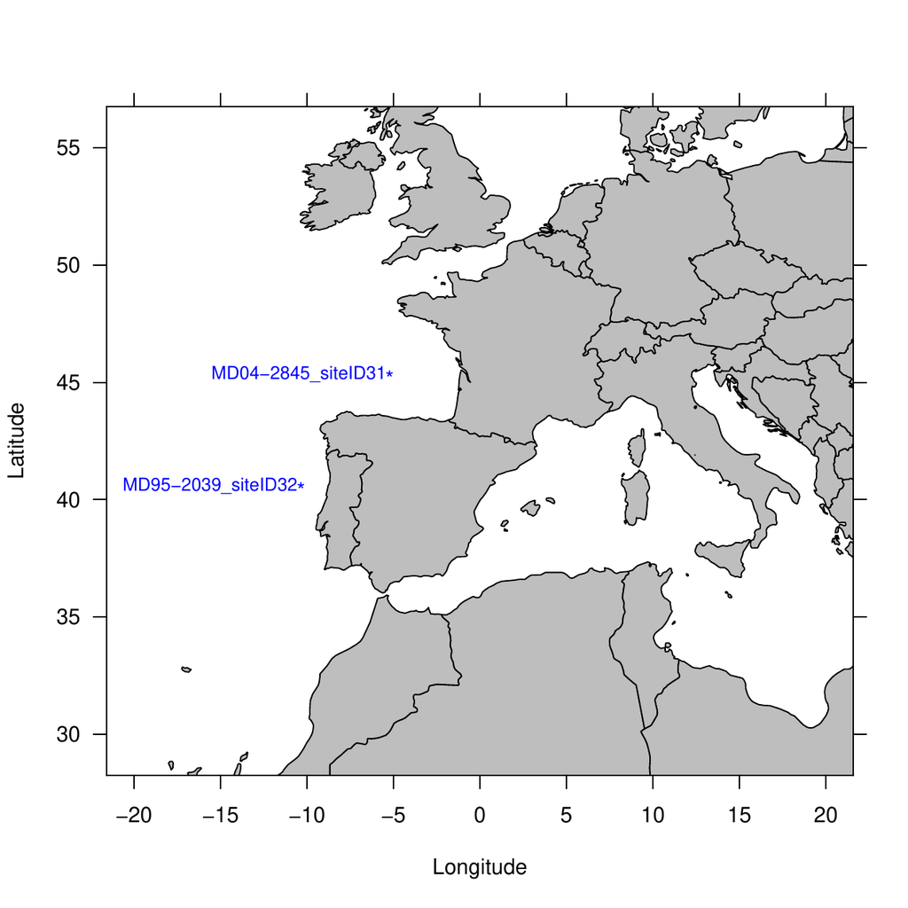

Figure 5: Geographical locations for the pollen time series under analysis (Sánchez Goñi et al. 2017). The labels indicate the names of the sites where the pollen data were obtained.

Figure 6 illustrates the variations in the pollen percentages of the temperate forest, a type of vegetation typical of moderate, warm, wet climates. Figure 6 A shows the primary and binned pollen records from site MD04-2845 (Sanchez Goni et al. 2008; Sánchez Goñi et al. 2017). Figure 6 B shows the primary and binned pollen records from site MD95-2039 (Roucoux et al. 2005; Sánchez Goñi et al. 2017). We use the pollen time series with a harmonised, consistent chronology (Sánchez Goñi et al. 2017) to carry out a fair comparison. We apply our `bin_cor` and `plot_ts` functions and obtain the binned time series, which have 27 elements, and a temporal distance between elements of 1220 years. The binned time series show a relatively high level of autocorrelation, $\hat{\bar{a}}'_{\mathrm{MD04-2845}} = 0.85$ and $\hat{\bar{a}}'_{\mathrm{MD95-2039}} = 0.80$, and an estimated bias-corrected persistence values of $\hat{\tau}_{\mathrm{MD04-2845}} = 3400$ years and $\bar{\tau}_{\mathrm{MD95-2039}} = 1300$ years. It can be observed from Figures 6 A and 6 B that the binned time series are roughly similar to the “primary” time series, although binning causes some information loss. This is due to the high degree of irregularity in the sampling of the “primary” time series, which makes it difficult to resample when the binned time series are built. In addition, information is lost because the length of the bin is dependent on the persistence and autocorrelation of the “primary” time series. Finally, Figures 6 C and 6 D show that the two pollen time series, presented as the primary and binned data, may be significantly correlated. This is discussed below.

A)

C)

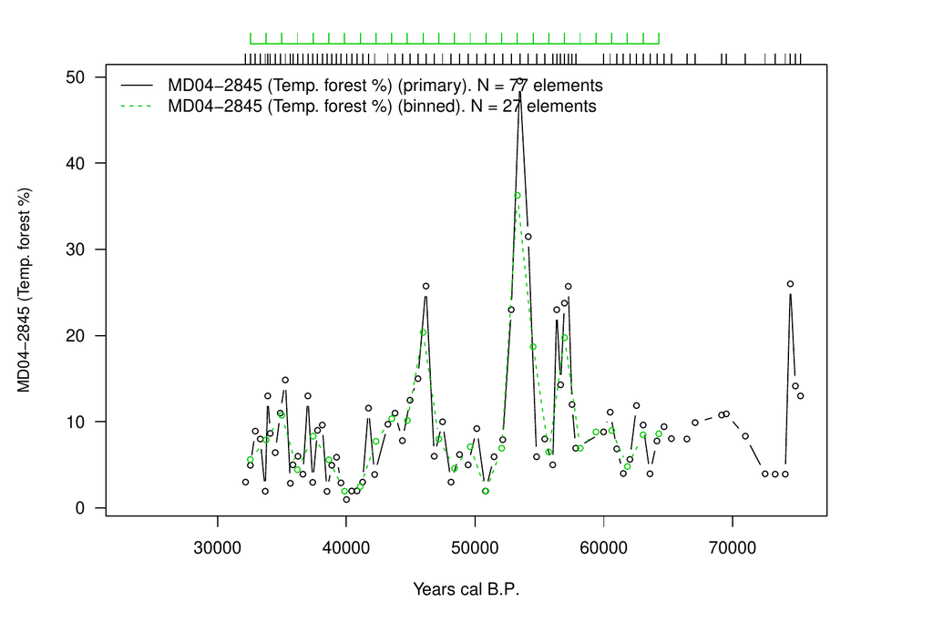

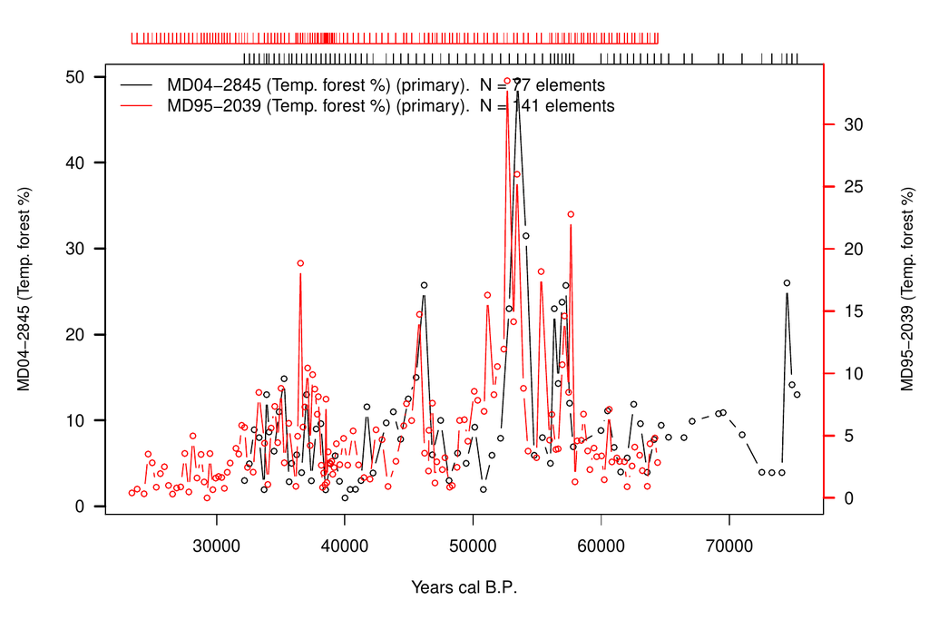

B)

D)

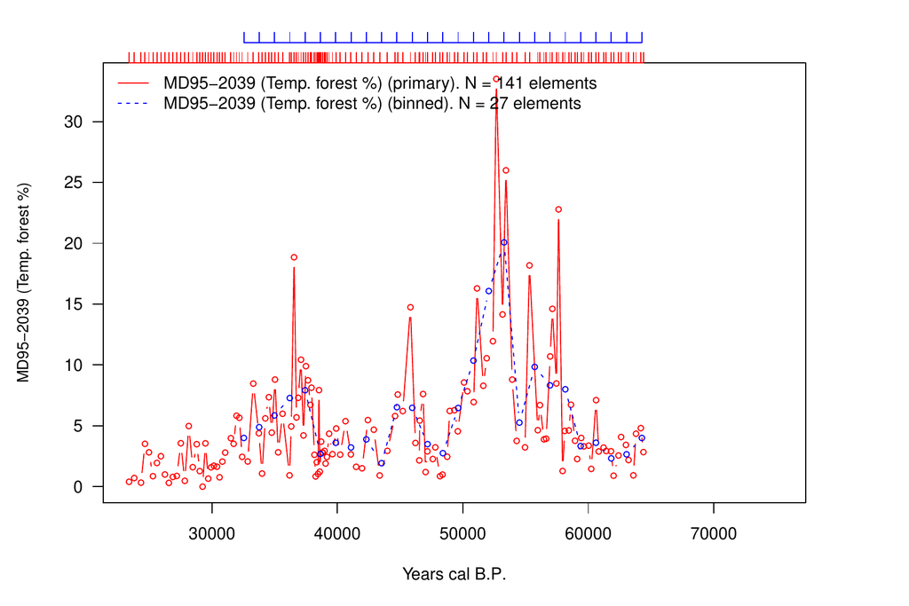

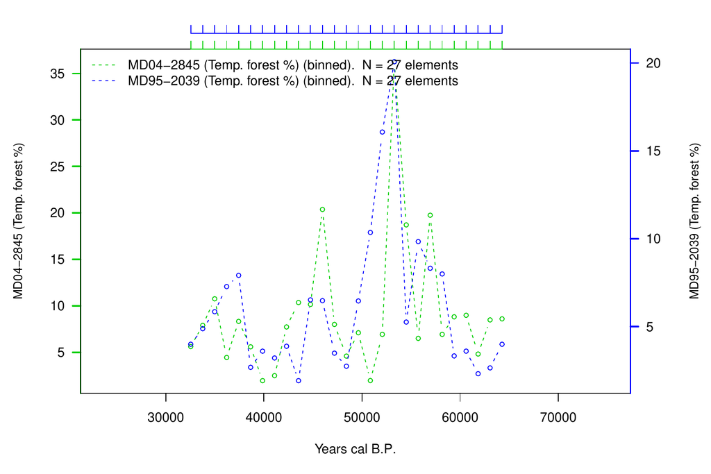

Figure 6: “Primary” (unevenly spaced) and binned pollen time series under analysis (**sanchez-goni_et_al_2017**). The numbers of elements for both time series are provided in the legend. The autocorrelation and persistence values for the time series from site MD04 are $\hat{\bar{a}}' = 0.85$ and *τ̂* = 3400 years, and those from site MD95 are $\hat{\bar{a}}' = 0.80$ and *τ* = 1300 years. The horizontal top axes indicate the sampling times for the plotted time series.

The code used to generate Figure 6 is as follows.

```r
 # Load the package
 library(BINCOR)
 library(pracma)

 # Load the time series under analysis: Example 2 and Figure 6
 data(MD04_2845_siteID31)
 data(MD95_2039_siteID32)

 # Compute the binned time series though our bin_cor function
 bincor.tmp <- bin_cor(ID31.dat, ID32.dat, FLAGTAU=3, "salida_ACER_ABRUPT.tmp")
 binnedts   <- bincor.tmp$Binned_time_series

 # To avoid NA values
 bin_ts1 <- na.omit(bincor.tmp$Binned_time_series[,1:2])
 bin_ts2 <- na.omit(bincor.tmp$Binned_time_series[,c(1,3)])

 # Applying our plot_ts function
 # PDF format
 plot_ts(ID31.dat, ID32.dat, bin_ts1, bin_ts2, "MD04-2845 (Temp. forest)",
 "MD95-2039 (Temp. forest )", colts1=1, colts2=2, colbints1=3, colbints2=4,
 device="pdf", Hpdf=6, Wpdf=9, resfig=300, ofilename="ts_ACER_ABRUPT")
```

The cross-correlation (CCF) analysis obtained with our `ccf_ts` function is shown in Figure 7. Before applying the `ccf_ts` function, a linear trend was removed from the binned time series by enabling the `rmltrd` option in `ccf_ts`, and then the residuals were used. The CCF reveals a high correlation ($r_{xy}$ = 0.53) between the binned time series at lag 0. The high correlation between the pollen records from sites MD04-2845 and MD95-2039 reflects similar responses by vegetation to regional climate variability, particularly to changes in precipitation and temperature. However, the most noticeable result in our CCF analysis is that the maximum correlation (r$_{xy}$ = 0.63) is obtained at lag 1. At face value, this result suggests that pollen variability at site MD04 leads that observed at site MD95-2039 by 1220 years. Nevertheless, these sites are located relatively close to each other and are in the same climate domain today, so it is difficult to envisage such a time difference in the response of vegetation (pollen) to rapid climatic changes in the past. The most plausible explanation for this out-of-phase relationship probably lies in the chronological uncertainties of the age models applied to these records. Despite best-efforts to harmonise the different time series in the ACER database using radiometric dating (Sánchez Goñi et al. 2017), the lack of $^{14}$C dates for site MD95-2039 forced us to build the age model for this site by tuning the planktic foraminifera and GRIP ice core oxygen isotopic records (Roucoux et al. 2005). This tuning could affect the time series from site MD95-2039 and introduce unacknowledged chronological uncertainties (Blaauw 2012; Hu et al. 2017). To summarise, with the present state of data quality we cannot rule out the idea that timescale uncertainties –rather than climate impact adaptation – caused the lag observed.

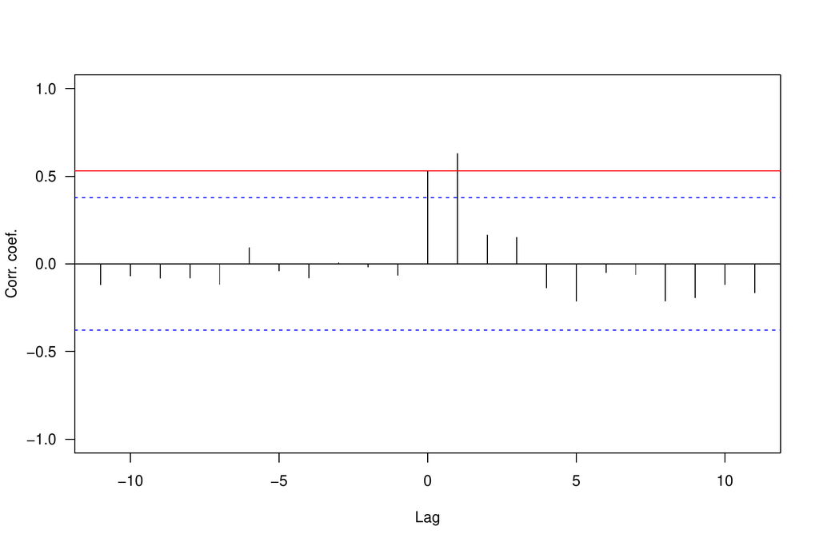

Figure 7: Cross-correlation for the residuals of the binned pollen time series from sites MD04 and MD95 (Sánchez Goñi et al. 2017). The CCF correlation coefficients at lag 0 and 1 are 0.53 and 0.63, respectively. The red line indicates the correlation coefficient for lag 0. Each lag is equivalent to 1220 years.

The code used to generate Figure 7 is the following.

```r
 # Load packages
 library(BINCOR)
 library(pracma)

 # Load the time series under analysis: Example 2 and Figure 7 (ID31 vs. ID32)
 data(MD04_2845_siteID31)
 data(MD95_2039_siteID32)

 # Compute the binned time series though our bin_cor function
 bincor.tmp <- bin_cor(ID31.dat, ID32.dat, FLAGTAU=3, "salida_ACER_ABRUPT.tmp")
 binnedts   <- bincor.tmp$Binned_time_series

 # To avoid NA values
 bin_ts1 <- na.omit(bincor.tmp$Binned_time_series[,1:2])
 bin_ts2 <- na.omit(bincor.tmp$Binned_time_series[,c(1,3)])

 # Applying our ccf_ts function
 # PDF format
 ccf_acf <- ccf_ts(bin_ts1, bin_ts2, RedL=TRUE, rmltrd="y", device="pdf", Hpdf=6,
 Wpdf=9, resfig=300, ofilename="ccf_ID31_ID32_res")
```

## 5 Summary

We present a computational package named *BINCOR* (BINned CORrelation) that can be used to estimate the correlation between two unevenly spaced climate time series which are not necessarily sampled at identical points in time, and between two evenly spaced time series which are not on the same time grid. *BINCOR* is based on a novel estimation approach proposed by (Mudelsee 2010). This statistical technique requires the concept of nonzero persistence times, thus enabling mixing information to be recovered, even when the two timescales examined differ (Mudelsee 2014). The package contains four functions (`bin_cor`, `cor_ts`, `ccf_ts` and `plot_ts`) with a number of parameters to obtain a high degree of flexibility in the analysis. *BINCOR* is programmed in `R` language and is available from the CRAN repository. The results when *BINCOR* s applied to real climate data sets suggest that the `R` package *BINCOR* performs and works properly in detecting relationships between instrumental and paleoclimate records.

## Acknowledgements

JMPM was funded by a Basque Government post-doctoral fellowship. MM’s work was supported by the European Commission via Marie Curie Initial Training Network LINC (project number 289447) under the Seventh Framework Programme. Thanks to Charo Sánchez for help to use the i2BASQUE HPC facilities, to the two anonymous reviewers and Editor (Olivia Lau) for their input and comments that have improved the quality of the manuscript. The authors thank the support of the computing infrastructure of the i2BASQUE (Basque Government) academic network. The persistence time estimation software is freely available via http://www.climate-risk-analysis.com/software/.

### 5.1 Supplementary materials

Supplementary materials are available in addition to this article. It can be downloaded at RJ-2019-035.zip

### 5.2 CRAN packages used

BINCOR, dplR, pracma, TSdist

### 5.3 CRAN Task Views implied by cited packages

DifferentialEquations, NumericalMathematics, TimeSeries

M. Blaauw. Out of tune: The dangers of aligning proxy archives. *Quaternary Science Reviews*, 36: 38–49, 2012. URL https://doi.org/10.1016/j.quascirev.2010.11.012.

H. W. Borchers. *pracma: Practical numerical math functions.* 2015. URL http://CRAN.R-project.org/package=pracma. R package version 1.8.8.

P. Brohan, J. J. Kennedy, I. Harris, S. F. Tett and P. D. Jones. Uncertainty estimates in regional and global observed temperature changes: A new data set from 1850. *Journal of Geophysical Research: Atmospheres*, 111(D12): 2006. URL http://dx.doi.org/10.1029/2005JD006548.

A. Bunn, M. Korpela, F. Biondi, F. Campelo, P. Merian, F. Qeadan, C. Zang, A. Buras, J. Cecile, M. Mudelsee, et al. *Dendrochronology program library in r.* 2015. URL http://CRAN.R-project.org/package=dplR. R package version 1.6.3.

W. Dansgaard, S. Johnsen, H. Clausen, D. Dahl-Jensen, N. Gundestrup, C. Hammer, C. Hvidberg, J. Steffensen, A. Sveinbjornsdottir, J. Jouzel, et al. Evidence for general instability of past climate from a 250-kyr ice-core record. *Nature*, 364(6434): 218–220, 1993. URL http://dx.doi.org/10.1038/364218a0.

J. Emile-Geay. *Data analysis in the earth & environmental sciences.* Ed. Figshare, 2016.

D. B. Enfield and D. A. Mayer. Tropical Atlantic sea surface temperature variability and its relation to El Nino-Southern Oscillation. *Journal of Geophysical Research: Oceans*, 102(C1): 929–945, 1997. URL http://dx.doi.org/10.1029/96JC03296.

E. Frentzos, K. Gratsias and Y. Theodoridis. Index-based most similar trajectory search. In *2007 IEEE 23rd international conference data engineering*, pages. 816–825 2007. URL http://dx.doi.org/10.1109/ICDE.2007.367927.

J. Garcia-Serrano, C. Cassou, H. Douville, A. Giannini and F. J. Doblas-Reyes. Revisiting the ENSO teleconnection to the Tropical North Atlantic. *Journal of Climate*, 30(17): 6945–6957, 2017. URL https://doi.org/10.1175/JCLI-D-16-0641.1.

D. L. Gilman, F. J. Fuglister and J. M. Mitchell Jr. On the power spectrum of “red noise.” *Journal of the Atmospheric Sciences*, 20(2): 182–184, 1963. URL https://doi.org/10.1175/1520-0469(1963)020<0182:OTPSON>2.0.CO;2.

L. Horowitz. The effects of spline interpolation on power spectral density. *IEEE Transactions on Acoustics, Speech, and Signal Processing*, 22(1): 22–27, 1974. URL http://dx.doi.org/10.1109/TASSP.1974.1162536.

J. Hu, J. Emile-Geay and J. Partin. Correlation-based interpretations of paleoclimate data–where statistics meet past climates. *Earth and Planetary Science Letters*, 459: 362–371, 2017. URL https://doi.org/10.1016/j.epsl.2016.11.048.

M. E. Mann and J. M. Lees. Robust estimation of background noise and signal detection in climatic time series. *Climatic Change*, 33(3): 409–445, 1996. URL https://doi.org/10.1007/BF00142586.

M. E. Mann, Z. Zhang, S. Rutherford, R. S. Bradley, M. K. Hughes, D. Shindell, C. Ammann, G. Faluvegi and F. Ni. Global signatures and dynamical origins of the Little Ice Age and Medieval Climate Anomaly. *Science*, 326(5957): 1256–1260, 2009. URL https://doi.org/10.1126/science.1177303.

U. Mori, A. Mendiburu and J. Lozano. TSdist: Distance measures for time series data. *R package version 3.4*, 2: 2015. URL http://CRAN.R-project.org/package=TSdist.

U. Mori, A. Mendiburu and J. A. Lozano. Distance measures for time series in R: The TSdist package. *R Journal*, 8(2): 451–459, 2016.

M. Mudelsee. *Climate Time Series Analysis: Classical Statistical and Bootstrap Methods.* Springer-Verlag, 2010.

M. Mudelsee. *Climate Time Series Analysis: Classical Statistical and Bootstrap Methods.* Second Springer-Verlag, 2014.

M. Mudelsee. Estimating Pearson’s correlation coefficient with bootstrap confidence interval from serially dependent time series. *Mathematical Geology*, 35(6): 651–665, 2003. URL https://doi.org/10.1023/B:MATG.0000002982.52104.02.

M. Mudelsee. TAUEST: A Computer Program for Estimating Persistence in Unevenly Spaced Weather/Climate Time Series. *Computers & Geosciences*, 28(1): 69–72, 2002. URL https://doi.org/10.1016/S0098-3004(01)00041-3.

K. Olafsdottir and M. Mudelsee. More accurate, calibrated bootstrap confidence intervals for estimating the correlation between two time series. *Mathematical Geosciences*, 46(4): 411–427, 2014. URL https://doi.org/10.1007/s11004-014-9523-4.

K. Rehfeld and G. Bedartha. *NESTOOLBOX – toolbox for the analysis of non-equidistantly sampled time series.* 2014. URL http://tocsy.pik-potsdam.de/nest.php. Matlab/Octave, version 1.01.

K. Rehfeld and J. Kurths. Similarity estimators for irregular and age-uncertain time series. *Climate of the Past*, 10(1): 107–122, 2014. URL https://doi.org/10.5194/cp-10-107-2014.

K. Rehfeld, N. Marwan, J. Heitzig and J. Kurths. Comparison of correlation analysis techniques for irregularly sampled time series. *Nonlinear Processes in Geophysics*, 18(3): 389–404, 2011. URL https://doi.org/10.5194/npg-18-389-2011.

J. Roberts, M. Curran, S. Poynter, A. Moy, T. van Ommen, T. Vance, C. Tozer, F. S. Graham, D. A. Young, C. Plummer, et al. Correlation confidence limits for unevenly sampled data. *Computers & Geosciences*, 104: 120–124, 2017. URL https://doi.org/10.1016/j.cageo.2016.09.011.

P. Robinson. Estimation of a time series model from unequally spaced data. *Stochastic Processes and their Applications*, 6(1): 9–24, 1977. URL https://doi.org/10.1016/0304-4149(77)90013-8.

K. Roucoux, L. De Abreu, N. Shackleton and P. Tzedakis. The response of NW Iberian vegetation to North Atlantic climate oscillations during the last 65 kyr. *Quaternary Science Reviews*, 24(14): 1637–1653, 2005. URL https://doi.org/10.1016/j.quascirev.2004.08.022.

M. F. Sanchez Goni, A. Landais, W. J. Fletcher, F. Naughton, S. Desprat and J. Duprat. Contrasting impacts of Dansgaard–Oeschger events over a western European latitudinal transect modulated by orbital parameters. *Quaternary Science Reviews*, 27(11): 1136–1151, 2008. URL https://doi.org/10.1016/j.quascirev.2008.03.003.

M. F. Sánchez Goñi, S. Desprat, A.-L. Daniau, F. C. Bassinot, J. M. Polanco-Martı́nez, S. P. Harrison, J. R. M. Allen, R. S. Anderson, H. Behling, R. Bonnefille, et al. The ACER pollen and charcoal database: A global resource to document vegetation and fire response to abrupt climate changes during the last glacial period. *Earth System Science Data*, 9(2): 679–695, 2017. URL https://doi.org/10.5194/essd-9-679-2017.

M. F. Sánchez Goñi and S. P. Harrison. Millennial-scale climate variability and vegetation changes during the Last Glacial: Concepts and terminology. *Quaternary Science Reviews*, 29(21): 2823–2827, 2010. URL https://doi.org/10.1016/j.quascirev.2009.11.014.

G. P. Weedon. *Time-Series Analysis and Cyclostratigraphy: Examining Stratigraphic Records of Environmental Cycles.* Cambridge Univ Press, Cambridge, 2003.

D. S. Wilks. *Statistical methods in the atmospheric sciences.* Academic press, 2011.

E. W. Wolff, S. P. Harrison, R. Knutti, M. F. Sanchez Goni, O. Wild, A.-L. Daniau, V. Masson-Delmotte, I. C. Prentice and R. Spahni. How has climate responded to natural perturbations? In *Understanding the earth system : Global change science for application*, Eds S. E. Cornell, I. C. Prentice, J. I. House and C. J. Downy pages. 72–101 2012. Cambridge University Press.